# Problem set 2

Akshita Gundavarapu

```python
import numpy as np
import pandas as pd
import matplotlib.pyplot as plt
```

## 1 Measures, values and relationships

### 1.1 & 1.2

```python
states = pd.read_csv("data /states.csv", sep ="\t")
states
```

|  | Population | Income | Illiteracy | LifeExp | Murder | HSGrad | Frost | Area |
| --- | --- | --- | --- | --- | --- | --- | --- | --- |
| 0 | 3615 | 3624 | 2.1 | 69.05 | 15.1 | 41.3 | 20 | 50708 |
| 1 | 365 | 6315 | 1.5 | 69.31 | 11.3 | 66.7 | 152 | 566432 |
| 2 | 2212 | 4530 | 1.8 | 70.55 | 7.8 | 58.1 | 15 | 113417 |
| 3 | 2110 | 3378 | 1.9 | 70.66 | 10.1 | 39.9 | 65 | 51945 |
| 4 | 21198 | 5114 | 1.1 | 71.71 | 10.3 | 62.6 | 20 | 156361 |
| 5 | 2541 | 4884 | 0.7 | 72.06 | 6.8 | 63.9 | 166 | 103766 |
| 6 | 3100 | 5348 | 1.1 | 72.48 | 3.1 | 56.0 | 139 | 4862 |
| 7 | 579 | 4809 | 0.9 | 70.06 | 6.2 | 54.6 | 103 | 1982 |
| 8 | 8277 | 4815 | 1.3 | 70.66 | 10.7 | 52.6 | 11 | 54090 |
| 9 | 4931 | 4091 | 2.0 | 68.54 | 13.9 | 40.6 | 60 | 58073 |
| 10 | 868 | 4963 | 1.9 | 73.60 | 6.2 | 61.9 | 0 | 6425 |
| 11 | 813 | 4119 | 0.6 | 71.87 | 5.3 | 59.5 | 126 | 82677 |
| 12 | 11197 | 5107 | 0.9 | 70.14 | 10.3 | 52.6 | 127 | 55748 |
| 13 | 5313 | 4458 | 0.7 | 70.88 | 7.1 | 52.9 | 122 | 36097 |
| 14 | 2861 | 4628 | 0.5 | 72.56 | 2.3 | 59.0 | 140 | 55941 |
| 15 | 2280 | 4669 | 0.6 | 72.58 | 4.5 | 59.9 | 114 | 81787 |
| 16 | 3387 | 3712 | 1.6 | 70.10 | 10.6 | 38.5 | 95 | 39650 |
| 17 | 3806 | 3545 | 2.8 | 68.76 | 13.2 | 42.2 | 12 | 44930 |
| 18 | 1058 | 3694 | 0.7 | 70.39 | 2.7 | 54.7 | 161 | 30920 |
| 19 | 4122 | 5299 | 0.9 | 70.22 | 8.5 | 52.3 | 101 | 9891 |
| 20 | 5814 | 4755 | 1.1 | 71.83 | 3.3 | 58.5 | 103 | 7826 |
| 21 | 9111 | 4751 | 0.9 | 70.63 | 11.1 | 52.8 | 125 | 56817 |
| 22 | 3921 | 4675 | 0.6 | 72.96 | 2.3 | 57.6 | 160 | 79289 |
| 23 | 2341 | 3098 | 2.4 | 68.09 | 12.5 | 41.0 | 50 | 47296 |
| 24 | 4767 | 4254 | 0.8 | 70.69 | 9.3 | 48.8 | 108 | 68995 |
| 25 | 746 | 4347 | 0.6 | 70.56 | 5.0 | 59.2 | 155 | 145587 |
| 26 | 1544 | 4508 | 0.6 | 72.60 | 2.9 | 59.3 | 139 | 76483 |
| 27 | 590 | 5149 | 0.5 | 69.03 | 11.5 | 65.2 | 188 | 109889 |
| 28 | 812 | 4281 | 0.7 | 71.23 | 3.3 | 57.6 | 174 | 9027 |
| 29 | 7333 | 5237 | 1.1 | 70.93 | 5.2 | 52.5 | 115 | 7521 |
| 30 | 1144 | 3601 | 2.2 | 70.32 | 9.7 | 55.2 | 120 | 121412 |
| 31 | 18076 | 4903 | 1.4 | 70.55 | 10.9 | 52.7 | 82 | 47831 |
| 32 | 5441 | 3875 | 1.8 | 69.21 | 11.1 | 38.5 | 80 | 48798 |
| 33 | 637 | 5087 | 0.8 | 72.78 | 1.4 | 50.3 | 186 | 69273 |
| 34 | 10735 | 4561 | 0.8 | 70.82 | 7.4 | 53.2 | 124 | 40975 |
| 35 | 2715 | 3983 | 1.1 | 71.42 | 6.4 | 51.6 | 82 | 68782 |
| 36 | 2284 | 4660 | 0.6 | 72.13 | 4.2 | 60.0 | 44 | 96184 |
| 37 | 11860 | 4449 | 1.0 | 70.43 | 6.1 | 50.2 | 126 | 44966 |
| 38 | 931 | 4558 | 1.3 | 71.90 | 2.4 | 46.4 | 127 | 1049 |
| 39 | 2816 | 3635 | 2.3 | 67.96 | 11.6 | 37.8 | 65 | 30225 |
| 40 | 681 | 4167 | 0.5 | 72.08 | 1.7 | 53.3 | 172 | 75955 |
| 41 | 4173 | 3821 | 1.7 | 70.11 | 11.0 | 41.8 | 70 | 41328 |
| 42 | 12237 | 4188 | 2.2 | 70.90 | 12.2 | 47.4 | 35 | 262134 |
| 43 | 1203 | 4022 | 0.6 | 72.90 | 4.5 | 67.3 | 137 | 82096 |
| 44 | 472 | 3907 | 0.6 | 71.64 | 5.5 | 57.1 | 168 | 9267 |
| 45 | 4981 | 4701 | 1.4 | 70.08 | 9.5 | 47.8 | 85 | 39780 |
| 46 | 3559 | 4864 | 0.6 | 71.72 | 4.3 | 63.5 | 32 | 66570 |
| 47 | 1799 | 3617 | 1.4 | 69.48 | 6.7 | 41.6 | 100 | 24070 |
| 48 | 4589 | 4468 | 0.7 | 72.48 | 3.0 | 54.5 | 149 | 54464 |
| 49 | 376 | 4566 | 0.6 | 70.29 | 6.9 | 62.9 | 173 | 97203 |

Popultion: ratio , integer with minimum being 0

Income: ratio, integer with minimum being 0

Literacy: interval, continuous with the minmum being 0

Life Expectancy: ratio, continuous with the minimum being 0

Murder: ratio, continuous

HS grad: ratio , continuous with the minimum being zero

Frost: ratio , integer with certain limits

Area: ratio , integer

### 1.3 Check if all values are within the range you specified. Are there any invalid values?

```python
print(states.Population.min(), states.Population.max())
print(states.Income.min(), states.Income.max())
print(states.Illiteracy.min(), states.Illiteracy.max())
print(states.LifeExp.min(), states.LifeExp.max())
print(states.Murder.min(), states.Murder.max())
print(states.HSGrad.min(), states.HSGrad.max())
print(states.Frost.min(), states.Frost.max())
print(states.Area.min(), states.Area.max())
```

```
365 21198
3098 6315
0.5 2.8
67.96 73.6
1.4 15.1
37.8 67.3
0 188
1049 566432
```

Values seem in the range. All values are positive which is what I expected

### 1.4 & 1.5

HS graduation rate and income: Are these variables of a measure type that permit to ask/answer such a question?

Yes these variables are of the type ratio. We could compare these variables usinga scatterplot.

What is your hypothesis: how might these variables be related? What do you think, why might it be like this?

I believe these variables are directly proportional to each other. So I would assume that states with high income may have a hogher highschool graduation rate.

### 1.6

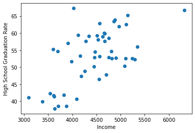

```python
_= plt.scatter(states.Income, states.HSGrad)
_ = plt.xlabel("Income")
_ = plt.ylabel("High School Graduation Rate")
```

From the scatter plot there seems to be a weak positive correlation betweek Income and Highschool Graduation rate. Thos would mean that the High school gradutation rate seems to be increasing as Income increase.

### 1.7

```python
m = states.HSGrad.median()
def education_level(rate):
    if rate < m:
        return 'less-educated'
    if rate > m:
        return 'more-educated'

states['education_level'] = states['HSGrad'].apply(education_level)
states
```

|  | Population | Income | Illiteracy | LifeExp | Murder | HSGrad | Frost | Area | education_level |
| --- | --- | --- | --- | --- | --- | --- | --- | --- | --- |
| 0 | 3615 | 3624 | 2.1 | 69.05 | 15.1 | 41.3 | 20 | 50708 | less-educated |
| 1 | 365 | 6315 | 1.5 | 69.31 | 11.3 | 66.7 | 152 | 566432 | more-educated |
| 2 | 2212 | 4530 | 1.8 | 70.55 | 7.8 | 58.1 | 15 | 113417 | more-educated |
| 3 | 2110 | 3378 | 1.9 | 70.66 | 10.1 | 39.9 | 65 | 51945 | less-educated |
| 4 | 21198 | 5114 | 1.1 | 71.71 | 10.3 | 62.6 | 20 | 156361 | more-educated |
| 5 | 2541 | 4884 | 0.7 | 72.06 | 6.8 | 63.9 | 166 | 103766 | more-educated |
| 6 | 3100 | 5348 | 1.1 | 72.48 | 3.1 | 56.0 | 139 | 4862 | more-educated |
| 7 | 579 | 4809 | 0.9 | 70.06 | 6.2 | 54.6 | 103 | 1982 | more-educated |
| 8 | 8277 | 4815 | 1.3 | 70.66 | 10.7 | 52.6 | 11 | 54090 | less-educated |
| 9 | 4931 | 4091 | 2.0 | 68.54 | 13.9 | 40.6 | 60 | 58073 | less-educated |
| 10 | 868 | 4963 | 1.9 | 73.60 | 6.2 | 61.9 | 0 | 6425 | more-educated |
| 11 | 813 | 4119 | 0.6 | 71.87 | 5.3 | 59.5 | 126 | 82677 | more-educated |
| 12 | 11197 | 5107 | 0.9 | 70.14 | 10.3 | 52.6 | 127 | 55748 | less-educated |
| 13 | 5313 | 4458 | 0.7 | 70.88 | 7.1 | 52.9 | 122 | 36097 | less-educated |
| 14 | 2861 | 4628 | 0.5 | 72.56 | 2.3 | 59.0 | 140 | 55941 | more-educated |
| 15 | 2280 | 4669 | 0.6 | 72.58 | 4.5 | 59.9 | 114 | 81787 | more-educated |
| 16 | 3387 | 3712 | 1.6 | 70.10 | 10.6 | 38.5 | 95 | 39650 | less-educated |
| 17 | 3806 | 3545 | 2.8 | 68.76 | 13.2 | 42.2 | 12 | 44930 | less-educated |
| 18 | 1058 | 3694 | 0.7 | 70.39 | 2.7 | 54.7 | 161 | 30920 | more-educated |
| 19 | 4122 | 5299 | 0.9 | 70.22 | 8.5 | 52.3 | 101 | 9891 | less-educated |
| 20 | 5814 | 4755 | 1.1 | 71.83 | 3.3 | 58.5 | 103 | 7826 | more-educated |
| 21 | 9111 | 4751 | 0.9 | 70.63 | 11.1 | 52.8 | 125 | 56817 | less-educated |
| 22 | 3921 | 4675 | 0.6 | 72.96 | 2.3 | 57.6 | 160 | 79289 | more-educated |
| 23 | 2341 | 3098 | 2.4 | 68.09 | 12.5 | 41.0 | 50 | 47296 | less-educated |
| 24 | 4767 | 4254 | 0.8 | 70.69 | 9.3 | 48.8 | 108 | 68995 | less-educated |
| 25 | 746 | 4347 | 0.6 | 70.56 | 5.0 | 59.2 | 155 | 145587 | more-educated |
| 26 | 1544 | 4508 | 0.6 | 72.60 | 2.9 | 59.3 | 139 | 76483 | more-educated |
| 27 | 590 | 5149 | 0.5 | 69.03 | 11.5 | 65.2 | 188 | 109889 | more-educated |
| 28 | 812 | 4281 | 0.7 | 71.23 | 3.3 | 57.6 | 174 | 9027 | more-educated |
| 29 | 7333 | 5237 | 1.1 | 70.93 | 5.2 | 52.5 | 115 | 7521 | less-educated |
| 30 | 1144 | 3601 | 2.2 | 70.32 | 9.7 | 55.2 | 120 | 121412 | more-educated |
| 31 | 18076 | 4903 | 1.4 | 70.55 | 10.9 | 52.7 | 82 | 47831 | less-educated |
| 32 | 5441 | 3875 | 1.8 | 69.21 | 11.1 | 38.5 | 80 | 48798 | less-educated |
| 33 | 637 | 5087 | 0.8 | 72.78 | 1.4 | 50.3 | 186 | 69273 | less-educated |
| 34 | 10735 | 4561 | 0.8 | 70.82 | 7.4 | 53.2 | 124 | 40975 | less-educated |
| 35 | 2715 | 3983 | 1.1 | 71.42 | 6.4 | 51.6 | 82 | 68782 | less-educated |
| 36 | 2284 | 4660 | 0.6 | 72.13 | 4.2 | 60.0 | 44 | 96184 | more-educated |
| 37 | 11860 | 4449 | 1.0 | 70.43 | 6.1 | 50.2 | 126 | 44966 | less-educated |
| 38 | 931 | 4558 | 1.3 | 71.90 | 2.4 | 46.4 | 127 | 1049 | less-educated |
| 39 | 2816 | 3635 | 2.3 | 67.96 | 11.6 | 37.8 | 65 | 30225 | less-educated |
| 40 | 681 | 4167 | 0.5 | 72.08 | 1.7 | 53.3 | 172 | 75955 | more-educated |
| 41 | 4173 | 3821 | 1.7 | 70.11 | 11.0 | 41.8 | 70 | 41328 | less-educated |
| 42 | 12237 | 4188 | 2.2 | 70.90 | 12.2 | 47.4 | 35 | 262134 | less-educated |
| 43 | 1203 | 4022 | 0.6 | 72.90 | 4.5 | 67.3 | 137 | 82096 | more-educated |
| 44 | 472 | 3907 | 0.6 | 71.64 | 5.5 | 57.1 | 168 | 9267 | more-educated |
| 45 | 4981 | 4701 | 1.4 | 70.08 | 9.5 | 47.8 | 85 | 39780 | less-educated |
| 46 | 3559 | 4864 | 0.6 | 71.72 | 4.3 | 63.5 | 32 | 66570 | more-educated |
| 47 | 1799 | 3617 | 1.4 | 69.48 | 6.7 | 41.6 | 100 | 24070 | less-educated |
| 48 | 4589 | 4468 | 0.7 | 72.48 | 3.0 | 54.5 | 149 | 54464 | more-educated |
| 49 | 376 | 4566 | 0.6 | 70.29 | 6.9 | 62.9 | 173 | 97203 | more-educated |

https://stackoverflow.com/questions/25570147/add-new-column-based-on-boolean-values-in-a-different-column

### 1.8

```python
states.groupby('education_level').HSGrad.mean()
```

```
education_level
less-educated    46.692
more-educated    59.524
Name: HSGrad, dtype: float64
```

I believe the results align with the the plot. Less educated states have a graduation rate of 46.7 while more educated states have a graduation rate of 59.5.

### 1.9

Based on your analysis, what do you think: do states have higher income because of more education, or the other way around: better income states can afford more education? Explain your reasoning!

I belive from our analysis, it is hard to tell which variable is independent and which variable is dependent. We may be able to understand this data better if we cound the same analyis with the reverse hypothesis and see which one gives us more clear results.

## 2 Explore inequality

```python
treatment =  pd.read_csv("data /treatment.csv", sep ="\t")
treatment
```

|  | treat | age | educ | ethn | married | re74 | re75 | re78 | u74 | u75 |
| --- | --- | --- | --- | --- | --- | --- | --- | --- | --- | --- |
| 0 | True | 37 | 11 | black | True | 0.0 | 0.0 | 9930.05 | True | True |
| 1 | True | 30 | 12 | black | False | 0.0 | 0.0 | 24909.50 | True | True |
| 2 | True | 27 | 11 | black | False | 0.0 | 0.0 | 7506.15 | True | True |
| 3 | True | 33 | 8 | black | False | 0.0 | 0.0 | 289.79 | True | True |
| 4 | True | 22 | 9 | black | False | 0.0 | 0.0 | 4056.49 | True | True |
| ... | ... | ... | ... | ... | ... | ... | ... | ... | ... | ... |
| 2670 | False | 47 | 8 | other | True | 44667.4 | 33837.1 | 38568.70 | False | False |
| 2671 | False | 32 | 8 | other | True | 47022.4 | 67137.1 | 59109.10 | False | False |
| 2672 | False | 47 | 10 | other | True | 48198.0 | 47968.1 | 55710.30 | False | False |
| 2673 | False | 54 | 0 | hispanic | True | 49228.5 | 44221.0 | 20540.40 | False | False |
| 2674 | False | 40 | 8 | other | True | 50940.9 | 55500.0 | 53198.20 | False | False |

2675 rows × 10 columns

```python
mag =  pd.read_csv("data /mag-30k-citations.csv", sep ="\t")
mag
```

|  | id | citations | year |
| --- | --- | --- | --- |
| 0 | 1926704088 | 10 | 2004 |
| 1 | 1590836146 | 0 | 1971 |
| 2 | 2035484488 | 3 | 2007 |
| 3 | 1965723909 | 0 | 2009 |
| 4 | 2021155615 | 42 | 1998 |
| ... | ... | ... | ... |
| 29995 | 1978075524 | 0 | 2014 |
| 29996 | 2055200684 | 1 | 2008 |
| 29997 | 2080698788 | 0 | 2012 |
| 29998 | 2004912114 | 11 | 2006 |
| 29999 | 2162869412 | 84 | 1990 |

30000 rows × 3 columns

```python
lunar = pd.read_csv("data /lunar-impact-craters_v08-2015-09.csv", sep ="\t")
lunar
```

|  | 1. Crater name | 2. Diameter [km] | 3. Latitude [°] | 4. Longitude [°] | 5. East longitude [°] | 6. Radius [km] | 7. Radius [m] | 8. Apparent diameter [km] | 9. Transient cavity diameter [km] | 10. Transient cavity diameter [km] | ... | 73. Average CF [μm] | 74. Average OMAT | 75. Average FeO [wt.-%] | 76. OMAT range | 77. Plg abundance class | 78. Province | 79. Peak degradation | 80. PAN location | 81. Rays | 1. Crater name .1 |
| --- | --- | --- | --- | --- | --- | --- | --- | --- | --- | --- | --- | --- | --- | --- | --- | --- | --- | --- | --- | --- | --- |
| 0 | Abbe | 63.98 | -57.58 | 174.77 | 174.77 | 32.0 | 31990 | 55.02 | 51.47 | 37.37 | ... | NaN | NaN | NaN | NaN | NaN | NaN | NaN | NaN | NaN | Abbe |
| 1 | Abbe H | 25.13 | -58.44 | 177.58 | 177.58 | 12.6 | 12565 | 21.61 | 23.26 | 15.60 | ... | NaN | NaN | NaN | NaN | NaN | NaN | NaN | NaN | NaN | Abbe H |
| 2 | Abbe K | 26.10 | -59.82 | 176.86 | 176.86 | 13.1 | 13050 | 22.45 | 24.02 | 16.17 | ... | NaN | NaN | NaN | NaN | NaN | NaN | NaN | NaN | NaN | Abbe K |
| 3 | Abbe M | 28.61 | -61.75 | 175.24 | 175.24 | 14.3 | 14305 | 24.60 | 25.97 | 17.61 | ... | NaN | NaN | NaN | NaN | NaN | NaN | NaN | NaN | NaN | Abbe M |
| 4 | Abbot | 10.40 | 5.56 | 54.74 | 54.74 | 5.2 | 5200 | 8.63 | 8.74 | 0.00 | ... | NaN | NaN | NaN | NaN | NaN | NaN | NaN | NaN | NaN | Abbot |
| ... | ... | ... | ... | ... | ... | ... | ... | ... | ... | ... | ... | ... | ... | ... | ... | ... | ... | ... | ... | ... | ... |
| 8711 | Zupus Z | 3.52 | -18.24 | -50.34 | 309.66 | 1.8 | 1760 | 2.92 | 2.96 | 0.00 | ... | NaN | NaN | NaN | NaN | NaN | NaN | NaN | NaN | NaN | Zupus Z |
| 8712 | Zwicky | 126.06 | -16.17 | 167.64 | 167.64 | 63.0 | 63030 | 108.41 | 91.60 | 70.44 | ... | NaN | NaN | NaN | NaN | NaN | NaN | NaN | NaN | NaN | Zwicky |
| 8713 | Zwicky N | 29.55 | -15.92 | 167.57 | 167.57 | 14.8 | 14775 | 25.41 | 26.69 | 18.16 | ... | NaN | NaN | NaN | NaN | NaN | NaN | NaN | NaN | NaN | Zwicky N |
| 8714 | Zwicky R | 28.99 | -18.13 | 163.59 | 163.59 | 14.5 | 14495 | 24.93 | 26.26 | 17.83 | ... | NaN | NaN | NaN | NaN | NaN | NaN | NaN | NaN | NaN | Zwicky R |
| 8715 | Zwicky S | 45.64 | -16.09 | 162.79 | 162.79 | 22.8 | 22820 | 39.25 | 38.62 | 27.25 | ... | NaN | NaN | NaN | NaN | NaN | NaN | NaN | NaN | NaN | Zwicky S |

8716 rows × 82 columns

(a) How many cases do we have in each data file?

- 2675 cases in treatment
- 30000 cases in mag
- 8716 cases in lunar

(b) Do the values of interest look reasonable?

```python
print(treatment.re78.min(), treatment.re78.max())
print(mag.citations.min(), mag.citations.max())
print(lunar['7. Radius [m]'].min(), lunar['7. Radius [m]'].max())
```

```
0.0 121174.0
0 7241
5 1250000
```

These values are all positive and their range seems reasonable.

### 2.1.2

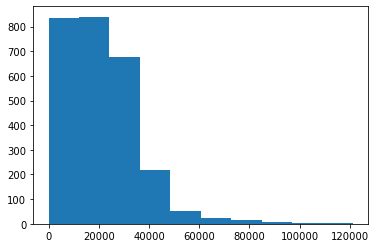

```python
tr = plt.hist(treatment.re78)
```

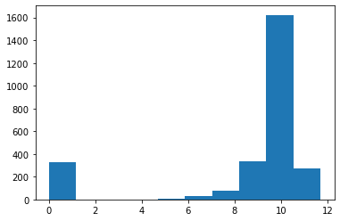

```python
treatment['natural_log'] = np.log(1 + treatment['re78'])
tr_log= plt.hist(treatment.natural_log)
```

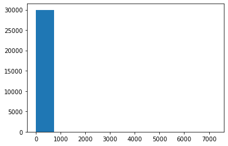

```python
mg = plt.hist(mag.citations)
```

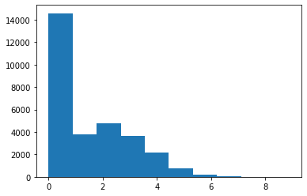

```python
mag['natural_log'] = np.log(1 + mag['citations'])
mg_log= plt.hist(mag.natural_log)
```

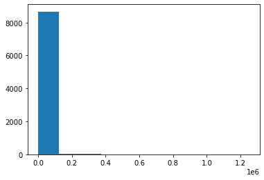

```python
lu = plt.hist(lunar['7. Radius [m]'])
```

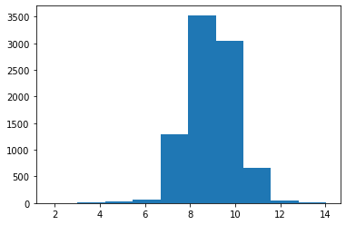

```python
lunar['natural_log'] = np.log(1 + lunar['7. Radius [m]'])
lu_log= plt.hist(lunar.natural_log)
```

### 2.1.3

Look at the histograms and tell-what do you think, which one describes the least unequal distribution, and which one the most unequal distribution?

From the histogram the data for the lunar radius seem to be the least unequal as the histogram appreas to bve normally distrubed when adjusted with the logarithmic scale. The data for the citations seems to be the most unequal as the histogram appears heavily skewed even on the logarithmic scale.

### 2.1.4

```python
print(treatment.re78.mean(), treatment.re78.std())
print(treatment.re78.mean() - treatment.re78.std())

print(mag.citations.mean(), mag.citations.std())
print(mag.citations.mean() - mag.citations.std())

print(lunar['7. Radius [m]'].mean(), lunar['7. Radius [m]'].std())
print(lunar['7. Radius [m]'].mean() - lunar['7. Radius [m]'].std())
```

```
20502.37607865417 15632.519774212507
4869.856304441664
15.605633333333333 79.17810312200979
-63.57246978867646
13711.492083524552 27505.543842011248
-13794.051758486696
```

Compare these: how much smaller (or larger) is std. dev compared to the mean? The citations data seems to have the lowest difference between the mean and standard deviation. The lunar radius data seems to have the greatest difference between the mean and standard deviation.

### 2.2.1

```python
def equality(value, total_value):
    for i in range(1, 51):
        top = np.percentile(value, 100-i)
        total = value[value > top].sum()
        if ((total/total_value) > (100-i)/100):
            i = i - 1
        if ((total/total_value) < (100-i)/100):
            i = i + 1
        else:
            value = i
            break
    return(value)

income = treatment.re78.dropna()
total_income = sum(treatment['re78'])
print(equality(income, total_income))

citations = mag.citations.dropna()
total_citations = sum(mag['citations'])
print(equality(citations, total_citations))

radius = lunar['7. Radius [m]']
total_radius = sum(lunar['7. Radius [m]'])
print(equality(radius, total_radius))
```

```
36
17
30
```

### 2.2.2

Which distribution is the most unequal one? Which one the most equal one? Does this corresponds to what did you guess based on the visual impression based on the histograms? From the ratios calculated it seems like income is the least unequal and citations seem to be the most unequal. This analysis somewhat matches my guess from the histograms because I also concluded that citations was the most unequal, however I said that lunar radius was the most equal, but that does not seem to be the case from our ratios.

## 3 Global temperature over time Are these variables of such a measure type that permit to ask/answer such a question? Global temerature is of the type ratio and years are of the type interval. These values can still be compared using a scatterplot.

```python
temp = pd.read_csv("data /UAH-lower-troposphere-wide.csv", sep ="\t")
temp
```

|  | year | month | globe | globe_land | globe_ocean | nh | nh_land | nh_ocean | sh | sh_land | ... | soext_ocean | nopol | nopol_land | nopol_ocean | sopol | sopol_land | sopol_ocean | usa48 | usa49 | aust |
| --- | --- | --- | --- | --- | --- | --- | --- | --- | --- | --- | --- | --- | --- | --- | --- | --- | --- | --- | --- | --- | --- |
| 0 | 1978 | 12 | -0.48 | -0.51 | -0.47 | -0.44 | -0.46 | -0.42 | -0.52 | -0.62 | ... | -0.45 | -0.39 | -0.68 | -0.06 | -0.45 | -0.38 | -0.49 | -1.29 | -1.15 | -1.29 |
| 1 | 1979 | 1 | -0.47 | -0.64 | -0.41 | -0.64 | -0.86 | -0.50 | -0.31 | -0.13 | ... | -0.29 | -0.46 | -0.95 | 0.10 | -0.16 | -0.15 | -0.16 | -3.22 | -2.42 | 0.92 |
| 2 | 1979 | 2 | -0.43 | -0.56 | -0.39 | -0.47 | -0.57 | -0.41 | -0.39 | -0.53 | ... | -0.36 | -2.00 | -2.30 | -1.66 | -0.80 | -1.25 | -0.58 | -1.76 | -1.84 | -0.30 |
| 3 | 1979 | 3 | -0.38 | -0.51 | -0.33 | -0.46 | -0.51 | -0.44 | -0.30 | -0.53 | ... | -0.21 | -0.56 | -0.47 | -0.65 | -0.53 | -1.25 | -0.18 | -0.70 | -0.38 | 0.23 |
| 4 | 1979 | 4 | -0.40 | -0.57 | -0.34 | -0.47 | -0.62 | -0.37 | -0.34 | -0.46 | ... | -0.31 | -0.84 | -0.81 | -0.87 | -0.26 | 0.26 | -0.51 | -0.72 | -0.46 | -1.12 |
| ... | ... | ... | ... | ... | ... | ... | ... | ... | ... | ... | ... | ... | ... | ... | ... | ... | ... | ... | ... | ... | ... |
| 512 | 2021 | 8 | 0.17 | 0.37 | 0.09 | 0.26 | 0.41 | 0.17 | 0.08 | 0.28 | ... | 0.02 | 0.83 | 1.08 | 0.55 | -0.14 | 0.41 | -0.40 | 0.32 | 0.28 | -0.02 |
| 513 | 2021 | 9 | 0.25 | 0.46 | 0.18 | 0.18 | 0.40 | 0.05 | 0.33 | 0.59 | ... | 0.37 | 0.02 | 0.05 | -0.02 | 0.32 | 0.74 | 0.12 | 0.67 | 0.32 | 0.37 |
| 514 | 2021 | 10 | 0.37 | 0.61 | 0.27 | 0.46 | 0.71 | 0.30 | 0.27 | 0.40 | ... | 0.24 | 0.63 | 0.72 | 0.53 | 0.11 | 0.85 | -0.24 | 0.84 | 0.58 | 0.06 |
| 515 | 2021 | 11 | 0.08 | 0.22 | 0.03 | 0.11 | 0.32 | -0.02 | 0.06 | 0.00 | ... | 0.06 | -0.43 | -0.19 | -0.70 | -0.72 | -0.67 | -0.75 | 0.50 | -0.06 | -0.29 |
| 516 | 2021 | 12 | 0.21 | 0.17 | 0.22 | 0.27 | 0.19 | 0.32 | 0.15 | 0.12 | ... | 0.25 | 0.01 | -0.25 | 0.31 | -0.42 | -0.24 | -0.51 | 1.63 | 1.42 | -0.06 |

517 rows × 29 columns

```python
print(temp.year.min(), temp.year.max())
print(temp.month.min(), temp.month.max())
print(temp.globe.min(), temp.globe.max())
print(temp.globe_land.min(), temp.globe_land.max())
print(temp.nh.min(), temp.nh.max())
print(temp.nh_land.min(), temp.nh_land.max())
print(temp.nh_ocean.min(), temp.nh_ocean.max())
print(temp.sh.min(), temp.sh.max())
print(temp.trpcs.min(), temp.trpcs.max())
```

[output not shown]

These values seem like they are within the normal range.

### 3.3

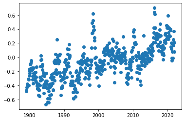

```python
temp["time"] = temp.year + (temp.month)/12

_ =plt.scatter(temp.time, temp.globe)
```

This scatterplot shows a weak positive correlation between time and temperature deviations.there also seems to be spikes in the plot for certain years.

### 3.4

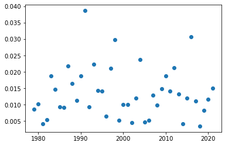

```python
var = temp.groupby("year").globe.var()
_ = plt.scatter(var.index, var)
```

### 3.5

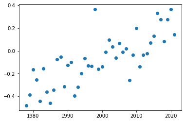

```python
yearly_temperature = temp.groupby("year").globe.median()
_ = plt.scatter(yearly_temperature.index, yearly_temperature)
```

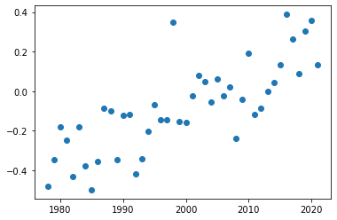

```python
yearly_temperature = temp.groupby("year").globe.mean()
_ = plt.scatter(yearly_temperature.index, yearly_temperature)
```

### 3.6

```python
temp['decades'] = (temp.year//10)*10
temp
```

[output not shown]

517 rows × 32 columns

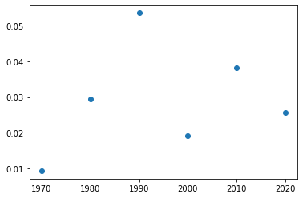

```python
var = temp.groupby("decades").globe.var()
_ = plt.scatter(var.index, var)
```

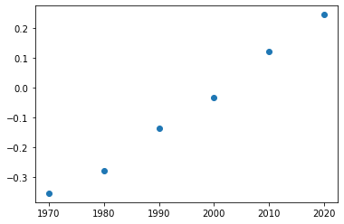

```python
decadal_temperature = temp.groupby("decades").globe.mean()
_ = plt.scatter(decadal_temperature.index, decadal_temperature)
```

### 3.7

```python
rows_2020 = np.shape(temp[temp.decades==2020])
print(rows_2020[0])
rows_1970 = np.shape(temp[temp.decades==1970])
print(rows_1970[0])

np.shape(temp[temp.decades == 1980])[0]
np.shape(temp[temp.decades == 1990])[0]
np.shape(temp[temp.decades == 2000])[0]
np.shape(temp[temp.decades == 2010])[0]
```

```
24
13
```

```
120
```

The data quality of the 1970 and 2020 may be poor because there may not be enough data collected from these decades. the other decades all have atleast 120 observations while the 1970's only have 13 observations and 2020's have only 24 observations, so this dataset may not be a good indicator of the temperatures variances in these decades. I believe this may be because there hasn't been enough data collected for these decades.

### 3.8

Discuss all your plots and state your conclusions: do you see any temperature trend? Do you see any trend in temporal variability? Which plots do you think illustrate your claims in the best way?

The yearly temperature plots show a positive correlation between time and temperature variances. I belive the decadal graph represents this trend in the best way because the points on this plot are neatly aligned to show a high positively correlated plot. The genral trend in the temporal variability would be that the temperature are rising as time is passes by.

This Assignment took me 15 hours.